# GoBike System Data Insights

## by Tarek Fayyad

## Investigation Overview

> In this investigation, I wanted to look at GoBike rental duration time and its interesting relationships with users age, users gender, users sbuscribtion type, distance between station, weekday and daily hours.

## Dataset Overview

> Bay Wheels is a regional public bicycle sharing system in California's San Francisco Bay Area.  
> This data set includes information about Ford GoBike individual ride for 183,412 trips.  
> Each trip information includes: duration in seconds, start_time, end_time, start_station_id, start_station_name, start_station_latitude, start_station_longitude, end_station_id, end_station_name, end_station_latitude, end_station_longitude, bike_id user_type, member_birth_year, member_gender and bike_share_for_all_trip.

## Distribution of GoBike Rental Duration

> - The rental duration averge between 1 to 35 minutes with averge of 9.7 minutes.
> - Users most frequent duration is 5.4 minutes.
> - 75% of duration range is about 12.7 minutes.

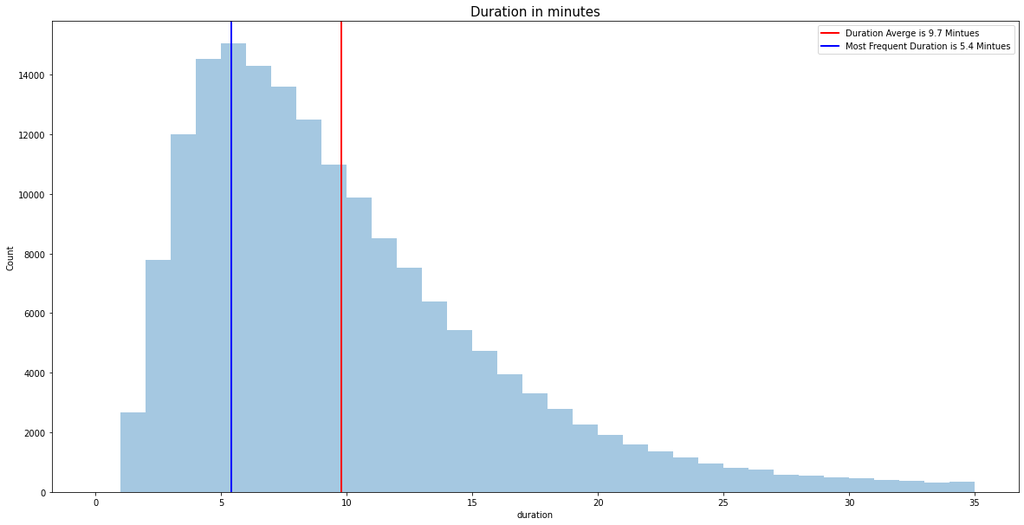

## Distribution of GoBike Rental Duration Vs Gender

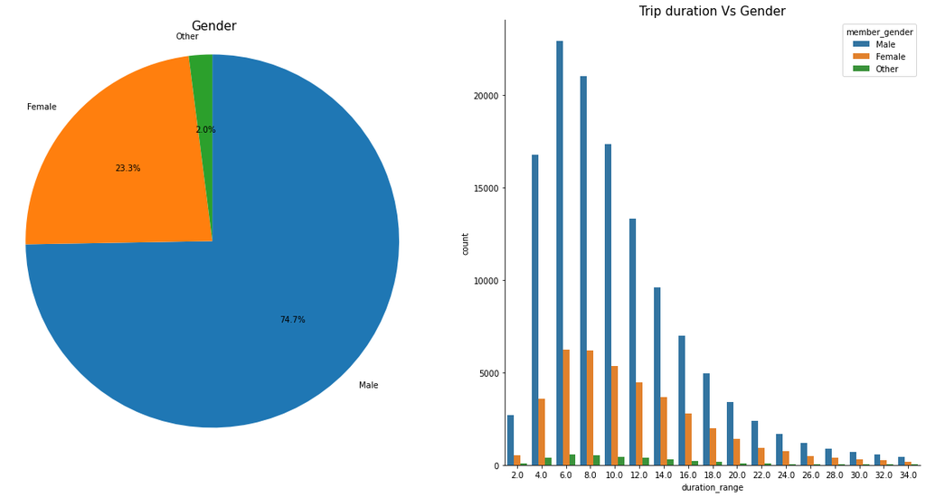

## Distribution of GoBike Rental Duration Vs Age

> - Age Distribution
>   > - Users age ranging from 18 to 69 years old with averge of 34 years old.
> - Users with age of 31 years old are the most frequent users of GoBike with averge duration of 10 minutes.
> - Users with age range from 24 to 33 years old are the most frequent users of GoBike with averge duration of 9.8 minutes.
> - Users with age range from 55 to 69 years old are the least frequent users of Gobike.
> - Users with 18 years old are rarely using GoBike.

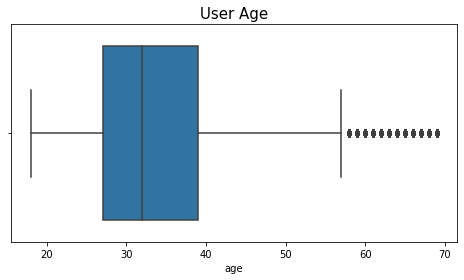

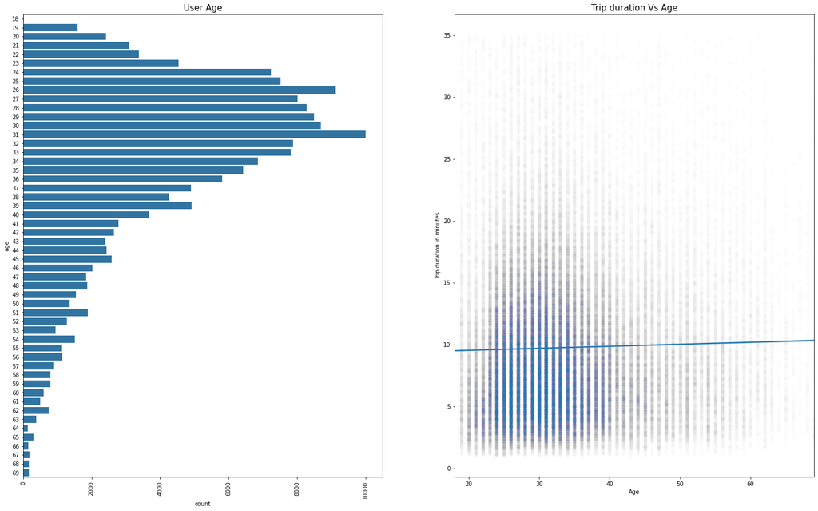

## Distribution of GoBike Rental Duration Vs Distance between station

> - Distance in meters Distribution
>   > - The distance range from 0 to 12410 meters with averge of 1686 meters.
>   > - Most of users make trip that range from 900 to 1500 meters.
>   > - There is a lot of distrubition at 0 distance which mean users return to start station
> - At 0 distance, duration range from 1 to 35 minutes with average duration of 12.7 minutes.
> - At distance > 0, duration range from 1 to 35 minutes with average of 9.7 minutes.

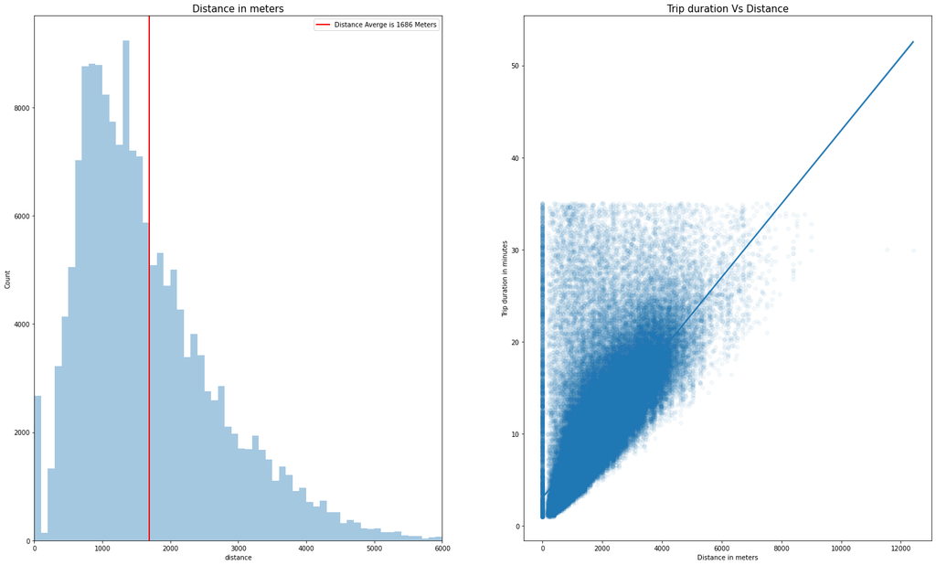

## Distribution of GoBike Rental Duration Vs Users Types

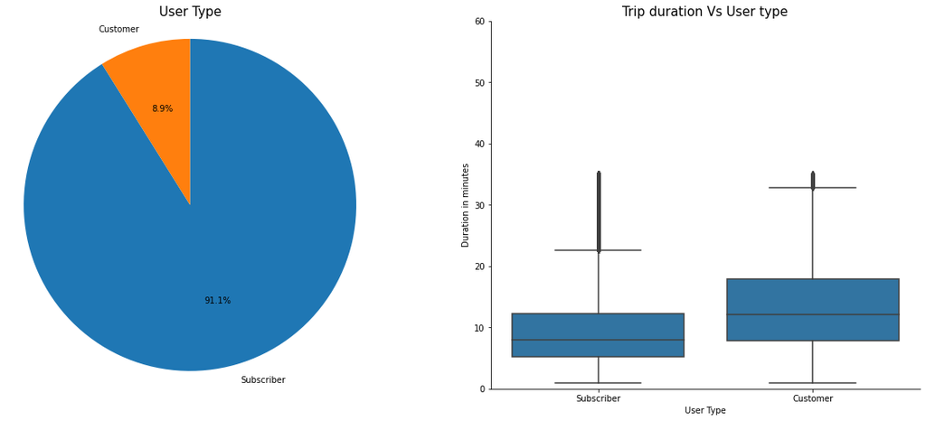

## GoBike Rental Duration Vs Age & Distance

> As distance between station increase , rental duration increase.  
> There is no correlation between age and duration.  
> There is no correlation between age and distance.

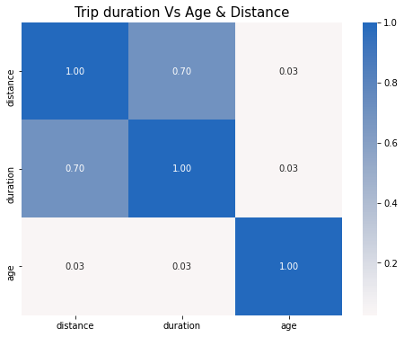

## GoBike Rental Duration Vs User type & Start Hour

> GoBike usage for Subscriber is almost the same regarding daily hour.  
> GoBike usage for customer differ according hour. The most usage is at 3,4,11,13,14 o'clock

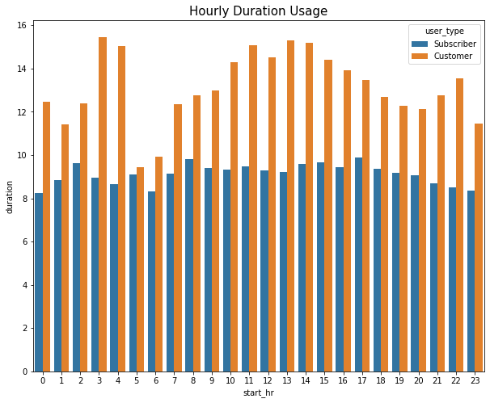

> Trip duration for Subscriber is almost the same regarding week day.  
> Trip duration for customer is higher than subscriber especially in Saturday and Sunday.

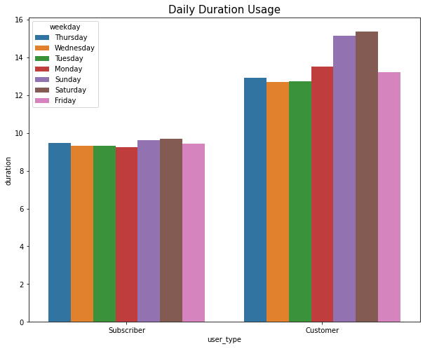

[output not shown]